# IBM Capstone Project: Battle of the Neighborhoods

Chicago Neighborhood Opportunity Fund Allocation

30 June, 2021

## Introduction

### Input-Output

#### Input

./data/ltdb/colorcode.csv  
./data/ltdb/ltdb_tracts_labeled.csv

#### Output

./data/ltdb/ltdb_series.RDS  
./data/ltdb/differenceMatrix.RDS  
./data/ltdb/ltdb_seq_cluster.RDS ./data/img/seqrplot.jpg

### Summary

See the main part of this project in Capstone_BattleOfNeighborhoods.ipynb.

While researching a topic for this capstone project I came across an academic paper that influenced where millions of dollars of development funds will be used. The "Neighborhood Opportunity Fund" [(NOF)](https://neighborhoodopportunityfund.com) in Chicago can award up to $2.5 million for individual projects in "Qualified Investment Areas". Information on the program explained that the geographic areas that were choosen to receive the grants was influenced by the study ["Mapping the DNA of Urban Neighborhoods: Clustering Longitudinal Sequences of Neighborhood Socioeconomic Change"](https://www.tandfonline.com/doi/full/10.1080/00045608.2015.1096188) by Elizabeth Delmelle.

I'm mostly replicating the study in Python

The orginal study used the R programming language and the package TraMineR to execute this algorithm. I didn't find any Python library that implements the algorithm. So at this point anyone executing the Python code would have to stop and continue by executing this R markup file, OMA.Rmd.

## Setup

```r
library(dplyr)
library(tidyverse)
library(TraMineR)
```

## Create OMA Input

Assume we have the file ./data/ltdb/colocode.csv and ./data/ltdb/ltdb_tracts_labeled.csv created by Capstone_BattleOfNeighborhoods.ipynb. The colorcode.csv file is to keep our visualizations consistent with those used in the Python notebook.

The ltdb_tracts_labeled.csv file is census tracts over several years classied by social-economic and demographic data using K-means. In the below cell we create series data for each census tract using the years in order. Then we save this dataframe to a RDS file for import into Python for later use.

```r
colorcode_csv=file.path(".", "data", "ltdb", "colorcode.csv")
colorcode=read.csv(colorcode_csv, colClasses = c("character","character", "character", "factor"))
ltdb_tracts_labeled_csv=file.path(".", "data", "ltdb", "ltdb_tracts_labeled.csv")
ltdb_tracts_labeled=read.csv(ltdb_tracts_labeled_csv, colClasses = c("character", "character", "factor"))

ltdb_series=ltdb_tracts_labeled %>% filter(year==1970) %>% select(CensusTract, label) %>% rename('1970'=label)
ltdb_series=full_join(ltdb_series, ltdb_tracts_labeled %>% filter(year==1980) %>% select(CensusTract, label) %>% rename('1980'=label), by='CensusTract')
ltdb_series=full_join(ltdb_series, ltdb_tracts_labeled %>% filter(year==1990) %>% select(CensusTract, label) %>% rename('1990'=label), by='CensusTract')
ltdb_series=full_join(ltdb_series, ltdb_tracts_labeled %>% filter(year==2000) %>% select(CensusTract, label) %>% rename('2000'=label), by='CensusTract')
ltdb_series=full_join(ltdb_series, ltdb_tracts_labeled %>% filter(year==2010) %>% select(CensusTract, label) %>% rename('2010'=label), by='CensusTract')
ltdb_series=full_join(ltdb_series, ltdb_tracts_labeled %>% filter(year==2019) %>% select(CensusTract, label) %>% rename('2019'=label), by='CensusTract')

ltdb_series_rds=file.path(".", "data", "ltdb", "ltdb_series.RDS")
saveRDS(ltdb_series, file = ltdb_series_rds)
```

## Running the OMA Algorithm

To determine which parameters to use I paid attention to the follow information from Dr. Delmelle's study

Document "Mapping the DNA of Urban Neighborhoods:" Section "Measuring Sequence Similarity"  
Page 8 on PDF (Page 42 printed in the document)  
*In this study, a transition rate substitution cost matrix produced the more favorable results.*

Page 9 on PDF (Page 43 printed in the document)  
*"insertion and deletion costs ...In this case, these costs are set at a value of 1"*

Then following the documentation from TraMineR, I concluded I should follow the below example:

Document "Analyzing and Visualizing State Sequences in R with TraMineR"  
Page 6  
*2. Compute pairwise optimal matching (OM) distances between sequences with an insertion/* *deletion cost of 1 and a substitution cost matrix based on observed transition* *rates:*

**R> mvad.om <- seqdist(mvad.seq, method = "OM", indel = 1, sm = "TRATE")**

The following cell sets up some custom colors imported from the Python code, then executes algorithm, and saves our difference matrix an RDS file for later import to Python

```r
ltdb.labels=c(colorcode[colorcode['numcode']==0, 'labels'], colorcode[colorcode['numcode']==1, 'labels'],
  colorcode[colorcode['numcode']==2, 'labels'], colorcode[colorcode['numcode']==3, 'labels'],
  colorcode[colorcode['numcode']==4, 'labels'])
ltdb.scodes=c(colorcode[colorcode['numcode']==0, 'scode'], colorcode[colorcode['numcode']==1, 'scode'],
              colorcode[colorcode['numcode']==2, 'scode'], colorcode[colorcode['numcode']==3, 'scode'],
              colorcode[colorcode['numcode']==4, 'scode'])
ltdb.colors=c(colorcode[colorcode['numcode']==0, 'color'], colorcode[colorcode['numcode']==1, 'color'],
              colorcode[colorcode['numcode']==2, 'color'], colorcode[colorcode['numcode']==3, 'color'],
              colorcode[colorcode['numcode']==4, 'color'])
ltdb.seq <- seqdef(ltdb_series, 2:7, states = ltdb.scodes, labels = ltdb.labels, cpal = ltdb.colors)
dist.om1 <- seqdist(ltdb.seq, method = "OM", indel = 1, sm = "TRATE")

differenceMatrix_rds=file.path(".", "data", "ltdb", "differenceMatrix.RDS")
saveRDS(dist.om1, file = differenceMatrix_rds)
```

## Clustering

At this point our goal of replicating and updating the original study becomes more complicated due to differences in features in R versus Python libraries. In the study Dr. Delmelle states <<"*In this case, a hierarchical Ward's clustering approach is applied to the data.*">> This works fine in R using the cluster library and function agnes. In python scikit-learn will only accept a matrix based on euclidean distance when using Ward's method.

I'll do the clustering here, write output to an RDS file for later import to the Python main program

```r
library(cluster)
clusterward1 <- agnes(dist.om1, diss = TRUE, method = "ward")
cl1.10 <- cutree(clusterward1, k = 10)
cl1.10fac <- factor(cl1.10, labels = paste("Cluster", 1:10))

ltdb_seq_cluster=data.frame(CensusTract = ltdb_series['CensusTract'], Rseqclust=c(cl1.10))
ltdb_seq_cluster_rds=file.path(".", "data", "ltdb", "ltdb_seq_cluster.RDS")
saveRDS(ltdb_seq_cluster, file = ltdb_seq_cluster_rds)
```

## Visualizations

Here I test out the legend. It conforms the colors and labels we imported from the main Python program.

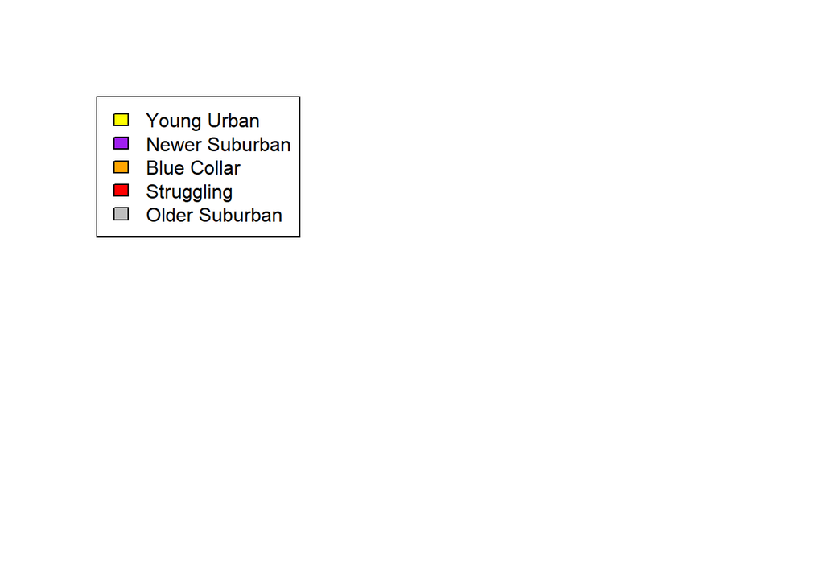

```r
seqlegend(ltdb.seq)
```

### Visualize All Sequences

Classifications in Dr. Delmelle's study "DNA of Urban Neighborhoods" don't match up exactly to what we see in our graphic

| Original | Mine | Description |
| --- | --- | --- |
| 1. | 7. | Struggling to Young Urban |
| 2. | 6. | Blue Collar to Young Urban |
| 3. | 3. | Stable Young Urban |
| 4. | 4. | Stable Older Suburban |
| 5. | 5. | Older Suburban to Blue Collar |
| 6. | 1. | Stable Struggling |
| 7. | 10. | Stable Blue Collar |
| 8. | NA | Blue Collar to Struggling. |
| 9. | 8. | New Suburban to Old Suburban |
| 10. | 9. | New Suburban |
| NA | 2. | Plurality Blue Collar with no dominate pattern |

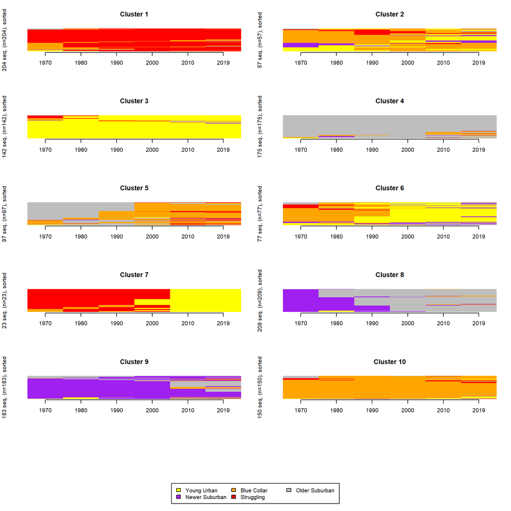

```r
par(mfrow = c(1, 1))
seqIplot(ltdb.seq, group = cl1.10fac, sortv = "from.start", yaxis=FALSE)
```

### Visualize Dominant Sequences

I don't like the above graphic so we will use the one that filters just the dominant sequences. Default is to display at least up to 25% of the dataset

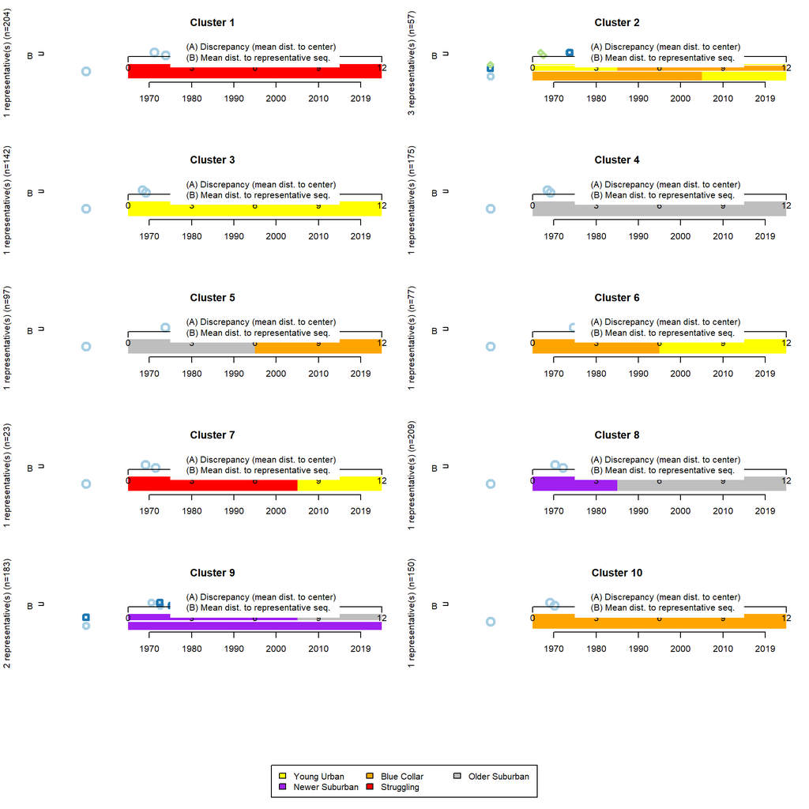

```r
seqrplot(ltdb.seq, diss = dist.om1, group = cl1.10fac, border = NA)
```

```r
par(mar=c(1,1,1,1))
```

Very good. Now save this to a JPEG for import into our main report

```r
seqrplot_jpg=file.path(".", "data", "img", "seqrplot.jpg")
jpeg(seqrplot_jpg, res=300, width = 2750, height = 3500)
seqrplot(ltdb.seq, diss = dist.om1, group = cl1.10fac, border = NA, coverage = 0.25)
dev.off()
```